# scikit-image RAG Introduction

Humans possess an incredible ability to identify objects in an image. Image processing algorithms are still far behind this ability. **Segmentation** is the process of identifying objects in an image. All pixels belonging to an object should get a unique label in an ideal segmentation.

In the example below, we will see how Region Adjacency Graphs (RAGs) attempt to solve this problem.

# Getting Started

The function `show_img` is defined so that images displayed are big enough for comfortable viewing. We start with `img`, a nice fresh image of a coffee cup.

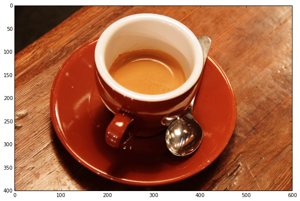

```python
from skimage import graph, data, io, segmentation, color
from matplotlib import pyplot as plt
from skimage.measure import regionprops
from skimage import draw
import numpy as np


def show_img(img):
    width = 10.0
    height = img.shape[0]*width/img.shape[1]
    f = plt.figure(figsize=(width, height))
    plt.imshow(img)

img = data.coffee()
show_img(img)
```

# Over Segmentation

We segment the image using SLIC algorithm. The segmentation algorithm will assign one unique label to what it perceives as a **Region**. This is a localized cluster of pixels sharing some similar proerpty, in this case their color. The label of each pixel is stored in the `labels` array.

`regionprops` helps us compute various features of these regions, the one we will be using (purely for visualization) is the centroid.

```python
labels = segmentation.slic(img, compactness=30, n_segments=400)
labels = labels + 1  # So that no labelled region is 0 and ignored by regionprops
regions = regionprops(labels)
```

The `label2rgb` function assigns a specific color to all pixels belonging to one region (having the same label). In this case, in `label_rgb` each pixel is replaces with the average `RGB` color of its region.

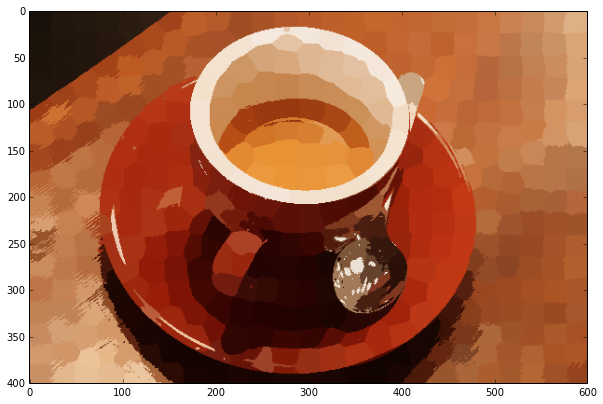

```python
label_rgb = color.label2rgb(labels, img, kind='avg')
show_img(label_rgb)
```

Just for clarity, we use `mark_boundaries` to highlight the region boundaries. You will notice the the image is divided into more regions than required. This phenomenon is called **Over-Segmentation**.

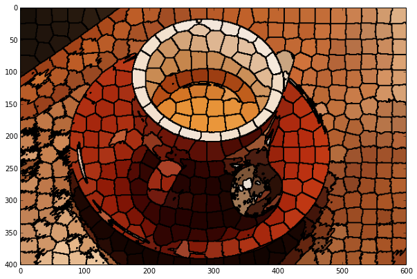

```python
label_rgb = segmentation.mark_boundaries(label_rgb, labels, (0, 0, 0))
show_img(label_rgb)
```

# Enter, RAGs

Region Adjacency Graphs, as the name suggests represent adjacency of regions with a graph. Each region in the image is a node in a graph. There is an edge between every pair of adjacent regions (regions whose pixels are adjacent). The weight of between every two nodes can be defined in a variety of ways. For this example, we will use the difference of average color between two regions as their edge weight. The more similar the regions, the lesser the weight between them. Because we are using difference in mean color to compute the edge weight, the method has been named `rag_mean_color`.

```python
rag = graph.rag_mean_color(img, labels)
```

For our visualization, we are also adding an additional property to a node, the coordinated of its centroid.

```python
for region in regions:
    rag.node[region['label']]['centroid'] = region['centroid']
```

`display_edges` is a function to draw the edges of a RAG on it's cooresponsing image. The edges are drawn in green. It also marks the centroid of each region by a yellow dot. It also takes an argument `thresh`, only edges with weight lower than `thresh` are drawn.

```python
def display_edges(img, rag, thresh):
    img = img.copy()
    for edge in rag.edges_iter(data=True):

        r1,r2,data = edge
        y1 = rag.node[r1]['centroid'][0]
        x1 = rag.node[r1]['centroid'][1]

        y2 = rag.node[r2]['centroid'][0]
        x2 = rag.node[r2]['centroid'][1]
        x1,x2,y1,y2 = int(x1),int(x2),int(y1),int(y2)
        line  = draw.line(y1,x1,y2,x2)
        circle = draw.circle(y1,x1,2)

        wt = data['weight']

        if wt < thresh :
            img[line] = 0,1,0
        img[circle] = 1,1,0

    return img
```

We call the function with `thresh = infinity` so that all edges are drawn. I myself was surprised with the beauty of the following output.

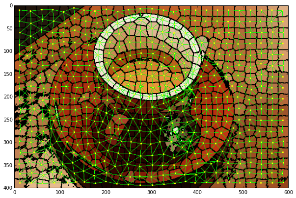

```python
edges_drawn_all = display_edges(label_rgb, rag, np.inf )
show_img(edges_drawn_all)
```

Let's see what happens by setting `thresh` to `30`, a value I arrived at with some trial and error.

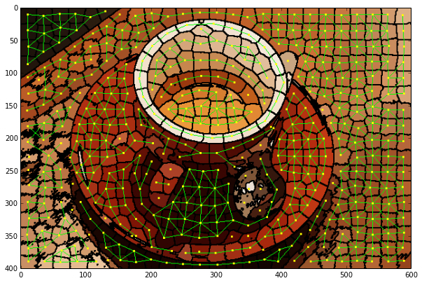

```python
edges_drawn_30 = display_edges(label_rgb, rag, 30 )
show_img(edges_drawn_30)
```

### Alas, the graph is cut

As you can see above, the RAG is now divided into disconnected regions. If you notice, the table above and to the right of the dish is one big connected component.

# Threshold Cut

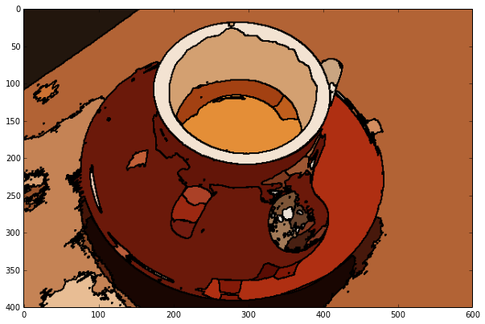

```python
final_labels = graph.cut_threshold(labels, rag, 30)
final_label_rgb = color.label2rgb(final_labels, img, kind='avg')
final_label_rgb = segmentation.mark_boundaries(final_label_rgb, final_labels, (0,0,0))
show_img(final_label_rgb)
```

### Not perfect, but not that bad I would say